# second week: Introduction to R and Rstudio

Mobile Data

Amirabbas Jalali 93105556

2018-02-19 15:32:44

# تمرین سری دوم: تلفن همراه شناسی!

> با استفاده از داده های گوشی های همراه به سوالات زیر پاسخ دهید. برای رسم نمودار از پکیج ggplot2 استفاده کنید.

۱. کدام شرکت بیشترین تعداد گوشی را تولید کرده است؟ نمودار ستونی ۲۰ شرکت برتر بر حسب تعداد گوشی تولید کرده را رسم کنید.

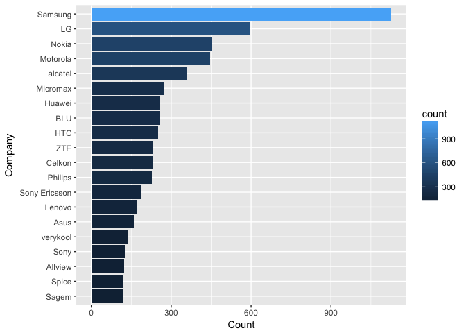

```r
library(ggplot2)
library(readr)
library(dplyr)

mobile = read_csv("../../Data/mobile_data.csv")
mobile_count = mobile %>% group_by(company) %>% summarise(count = n())

top_50_mobile_count = head(mobile_count[order(mobile_count$count, decreasing=TRUE), ], 20)

p = ggplot(data = top_50_mobile_count, aes(y = count, x = reorder(company, count), fill = count)) + geom_bar(stat="identity") + xlab("Company") + ylab("Count") + coord_flip()
p
```

کمپانی ای که بیشترین گوشی را تولید کرده و تعداد گوشی های تولید شده توسط این کمپانی در زیرآمده است.

```r
print(top_50_mobile_count$company[1])
```

```
[1] "Samsung"
```

```r
print(top_50_mobile_count$count[1])
```

```
[1] 1127
```

۲. نمودار زمانی طول عرض ضخامت و کیفیت دوربین گوشی ها را بکشید و به نمودار هر یک مدل خطی اضافه کنید.

```r
library(ggplot2)
library(readr)
library(dplyr)

mobile = read_csv("../../Data/mobile_data.csv")
mobile_length = mobile %>% group_by(year) %>% summarise(avg = mean(dim_length, na.rm = TRUE))
mobile_width = mobile %>% group_by(year) %>% summarise(avg = mean(dim_breadth, na.rm = TRUE))
mobile_height = mobile %>% group_by(year) %>% summarise(avg = mean(dim_thickness, na.rm = TRUE))
mobile_cam = mobile %>% group_by(year) %>% summarise(avg = mean(cam_px, na.rm = TRUE))

# raw data
```

این نمودار طول گوشی ها را در سال های اشاره شده نشان می دهد.

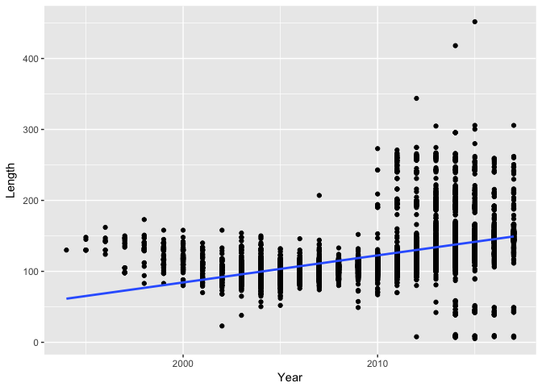

```r
p_l_2 = ggplot(data = mobile, aes(y = dim_length, x = year)) + geom_point(stat="identity") + xlab("Year") + ylab("Length") +  geom_smooth(method = "lm", span = 0.5 , se = FALSE)
p_l_2
```

این نمودار عرض گوشی ها را در سال های اشاره شده نشان می دهد.

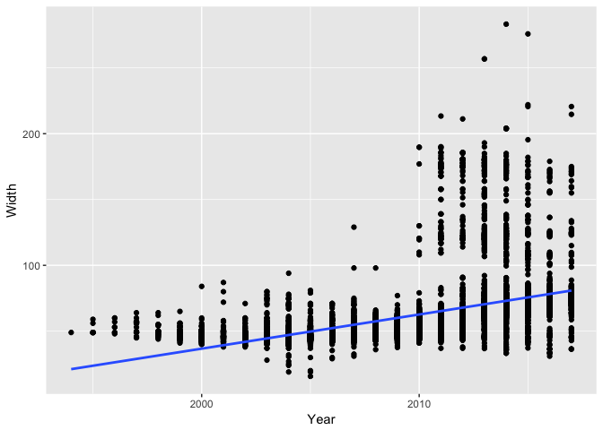

```r
p_w_2 = ggplot(data = mobile, aes(y = dim_breadth, x = year)) + geom_point(stat="identity") + xlab("Year") + ylab("Width") +  geom_smooth(method = "lm", span = 0.7 , se = FALSE)
p_w_2
```

این نمودار ارتفاع گوشی ها را در سال های اشاره شده نشان می دهد.

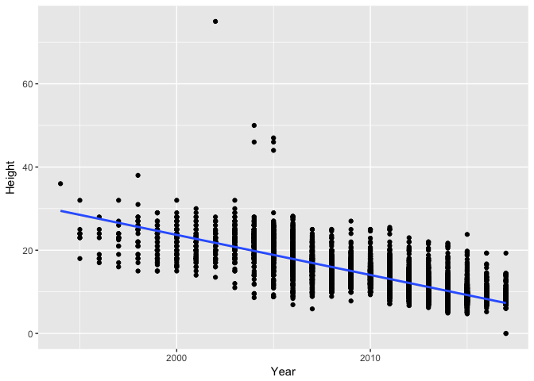

```r
p_h_2 = ggplot(data = mobile, aes(y = dim_thickness, x = year)) + geom_point(stat="identity") + xlab("Year") + ylab("Height") +  geom_smooth(method = "lm", span = 0.5 , se = FALSE)
p_h_2
```

این نمودار کیفیت دوربین گوشی ها را در سال های اشاره شده نشان می دهد.

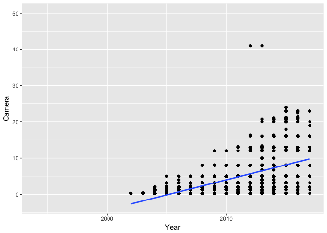

```r
p_c_2 = ggplot(data = mobile, aes(y = cam_px, x = year)) + geom_point(stat="identity") + xlab("Year") + ylab("Camera") +  geom_smooth(method = "lm", span = 0.5 , se = FALSE)
p_c_2
```

این نمودار میانگین طول گوشی ها را در سال های اشاره شده نشان می دهد.

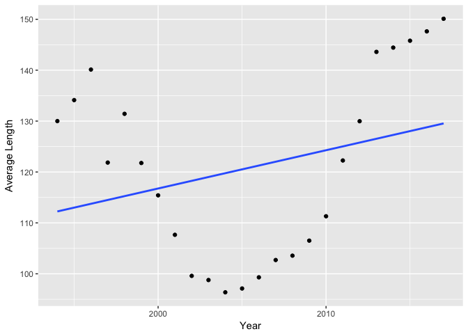

```r
# avrage

p_l = ggplot(data = mobile_length, aes(y = avg, x = year)) + geom_point(stat="identity") + xlab("Year") + ylab("Average Length") +  geom_smooth(method = "lm", span = 0.5 , se = FALSE)
p_l
```

این نمودار میانگین عرض گوشی ها را در سال های اشاره شده نشان می دهد.

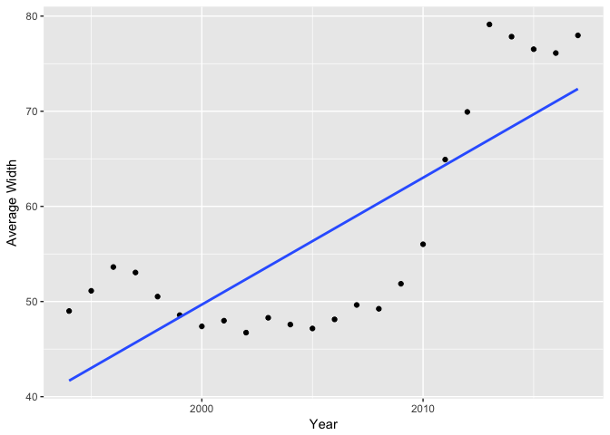

```r
p_w = ggplot(data = mobile_width, aes(y = avg, x = year)) + geom_point(stat="identity") + xlab("Year") + ylab("Average Width") +  geom_smooth(method = "lm", span = 0.7 , se = FALSE)
p_w
```

این نمودار میانگین ارتفاع گوشی ها را در سال های اشاره شده نشان می دهد.

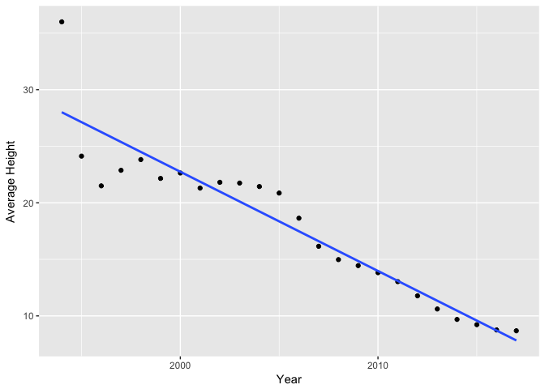

```r
p_h = ggplot(data = mobile_height, aes(y = avg, x = year)) + geom_point(stat="identity") + xlab("Year") + ylab("Average Height") +  geom_smooth(method = "lm", span = 0.5 , se = FALSE)
p_h
```

این نمودار میانگین کیفیت دوربین گوشی ها را در سال های اشاره شده نشان می دهد.

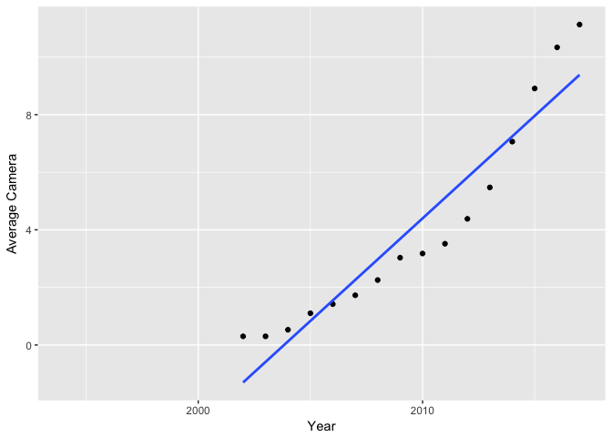

```r
p_c = ggplot(data = mobile_cam, aes(y = avg, x = year)) + geom_point(stat="identity") + xlab("Year") + ylab("Average Camera") +  geom_smooth(method = "lm", span = 0.5 , se = FALSE)
p_c
```

۳. نمودار ستونی متوسط قیمت گوشی بر حسب تعداد سیم کارت و دسترسی به LTE را رسم نمایید.

```r
library(ggplot2)
library(readr)
library(dplyr)

mobile = read_csv("../../Data/mobile_data.csv")
mobile$ls = interaction(mobile$LTE,mobile$sim_no)
mobile_price = mobile %>% group_by(sim_no) %>% summarise(avg = mean(price, na.rm = TRUE))
mobile_price_LTE = mobile %>% group_by(LTE) %>% summarise(avg = mean(price, na.rm = TRUE))
mobile_price_LTE_sim = mobile %>% group_by(ls) %>% summarise(avg = mean(price, na.rm = TRUE))
```

بر حسب تعداد سیم کارت

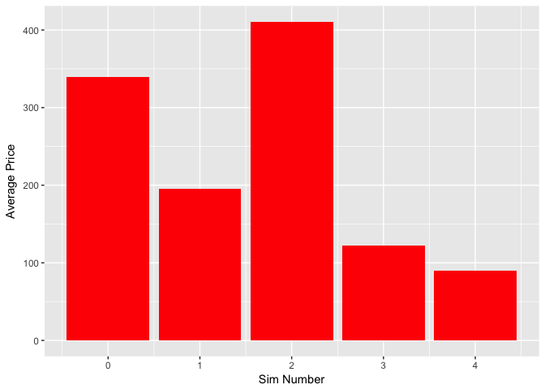

```r
p_p = ggplot(data = mobile_price, aes(y = avg, x = sim_no)) + geom_bar(stat="identity", fill = "red") + xlab("Sim Number") + ylab("Average Price")
p_p
```

بر حسب دسترسی به LTE

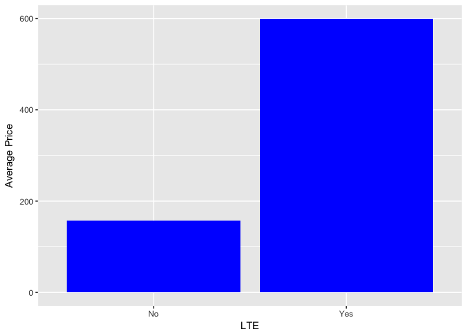

```r
p_l = ggplot(data = mobile_price_LTE, aes(y = avg, x = LTE)) + geom_bar(stat="identity", fill = "blue") + xlab("LTE") + ylab("Average Price")
p_l
```

برحسب جفت متغیرها

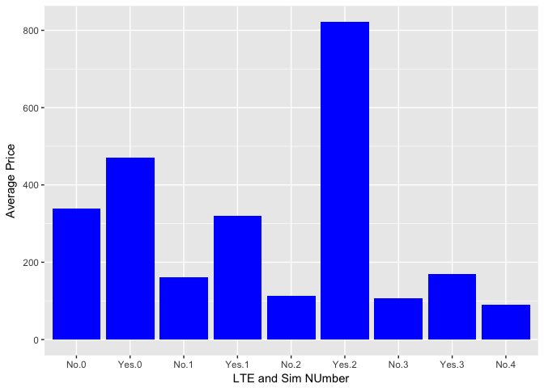

```r
p_l_s = ggplot(data = mobile_price_LTE_sim, aes(y = avg, x = ls)) + geom_bar(stat="identity", fill = "blue") + xlab("LTE and Sim NUmber") + ylab("Average Price")
p_l_s
```

۴. نمودار جعبه ایی ضحامت گوشی هایی که در سال ۲۰۱۷ معرفی شده اند را برحسب اینکه کمیت جک هدفون رسم نمایید

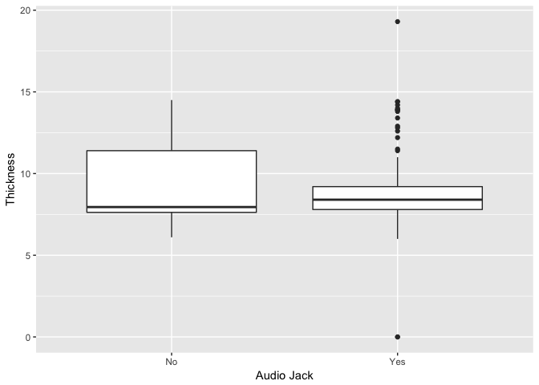

```r
library(ggplot2)
library(readr)
library(dplyr)

mobile = read_csv("../../Data/mobile_data.csv")

mobile_2017 = mobile[which(mobile$year == 2017),]

p = ggplot(mobile_2017, aes(y = dim_thickness , x = audio_jack)) + geom_boxplot() + xlab("Audio Jack") + ylab("Thickness")
p
```

۵. مفهوم ppi را در گوشی های موبایل محاسبه و هیستوگرام آن را رسم نمایید.

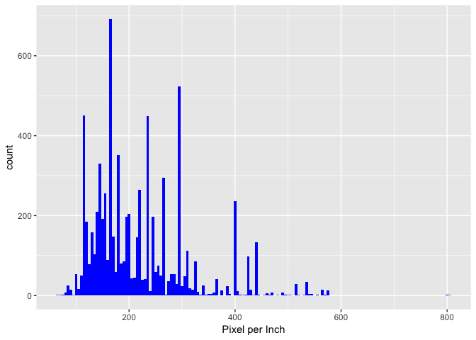

```r
library(ggplot2)
library(readr)
library(dplyr)

mobile = read_csv("../../Data/mobile_data.csv")

mobile_ppi = mobile %>% mutate(ppi = (sqrt((px_row)^2+(px_col)^2))/display_size) %>% filter(!is.na(ppi))

p_p = ggplot(mobile_ppi, aes(ppi)) + geom_histogram(binwidth = 5, fill = "blue") + xlab("Pixel per Inch")
p_p
```

همچنین نمودار سالانه متوسط این کمیت را بکشید.

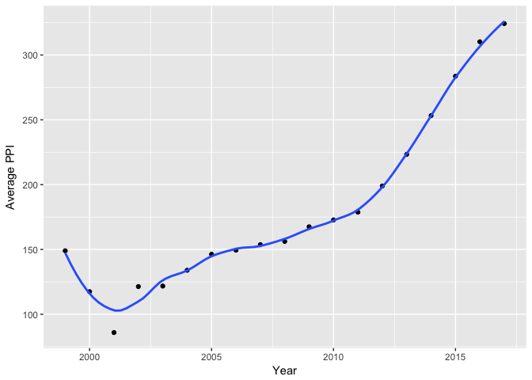

```r
mobile_ppi_year = mobile_ppi %>% group_by(year) %>% summarise(avg = mean(ppi, na.rm = TRUE))

p_p_y = ggplot(mobile_ppi_year, aes(x = year, y = avg)) + geom_point() + geom_smooth(span = 0.4 , se = FALSE) + xlab("Year") + ylab("Average PPI")
p_p_y
```

کدام گوشی بیشترین ppi را دارد؟

```r
most_ppi = head(mobile_ppi[order(mobile_ppi$ppi, decreasing=TRUE), ], 1)
print(most_ppi$company)
```

```
[1] "Sony"
```

```r
print(most_ppi$device)
```

```
[1] "Xperia XZ Premium"
```

```r
print(most_ppi$ppi)
```

```
[1] 806.9257
```

۶. در گذشته به بعضی از مدل های گوشی نوکیا **گوشکوب** گفته می شد. سعی کنید برای این مفهوم کمیتی مناسب تعریف کنید . ده گوشکوب برتر را پیدا کرده و نمودار گوشکوبیت آن را رسم نمایید.

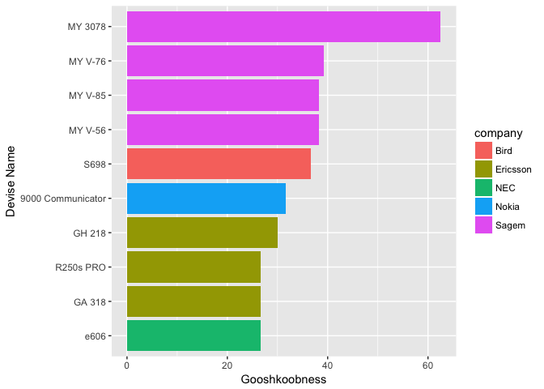

```r
library(ggplot2)
library(readr)
library(dplyr)

mobile = read_csv("../../Data/mobile_data.csv")

gooshkoobs = mobile[which(mobile$dim_thickness > 17),]
gooshkoobs = gooshkoobs[which(gooshkoobs$display_size < 2 | is.na(gooshkoobs$display_size)),]
gooshkoobs$display_size[is.na(gooshkoobs$display_size)] <- 1.2

gooshkoobs = gooshkoobs %>% mutate(gooshkoobness = dim_thickness/display_size)
top_10_gooshkoobs = head(gooshkoobs[order(gooshkoobs$gooshkoobness, decreasing=TRUE), ], 10)

p = ggplot(top_10_gooshkoobs, aes(x = reorder(device, gooshkoobness) , y = gooshkoobness, lable = company, fill = company)) + geom_bar(stat="identity") + xlab("Devise Name") + ylab("Gooshkoobness") + coord_flip()
p
```

۷. آیا تلفن همراهی وجود دارد که در آب غرق نشود؟  
بله  
اگر جواب بله هست تمام گوشی های که این خاصیت را دارند بیابید. با کشیدن یک نمودار به این سوال پاسخ دهید.

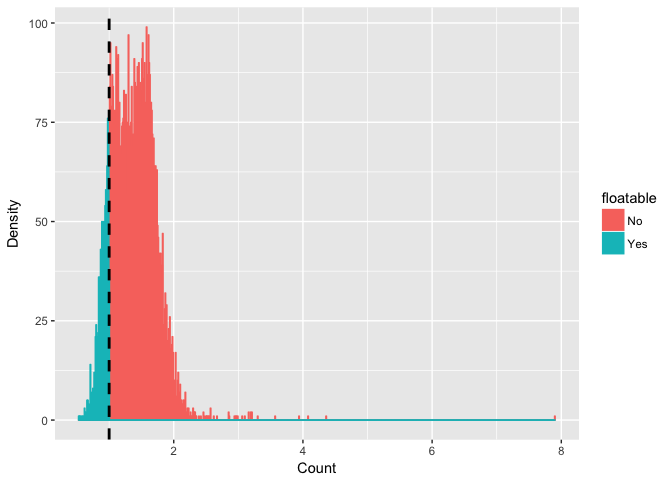

```r
library(ggplot2)
library(readr)
library(dplyr)

mobile = read_csv("../../Data/mobile_data.csv")

mobile_dnst = mobile %>% mutate(dnst = (weight/((dim_length)*(dim_thickness)*(dim_breadth)))*1000, floatable = ifelse(dnst < 1, "Yes", "No")) %>% filter(!is.na(dnst))

mobile_dnst_floating = mobile_dnst[which(mobile_dnst$floatable == "Yes"),]
mobile_dnst_floating = mobile_dnst_floating %>% select(company, device)

p = ggplot(mobile_dnst, aes(x = dnst, fill = floatable, color = floatable)) + geom_histogram(position="identity", binwidth = 0.01) + geom_vline(aes(xintercept=1), size = 1, linetype = "dashed") + xlab("Count") + ylab("Density")
p
```

نمودار بالا هیستوگرامی بر میزان چگالی گوشی ها می باشد که در قسمت آبی گوشی هایی که شناور میشوند را شاهد هستیم و در قسمت نارنجی گوشی هایی که غرق می شوند.  
تمام گوشی هایی که شناور می شوند یه همراه کمپانی سازنده ی آنها در متغیر mobile_dnst_floating موجودند.

۸. نمودار پراکنش حجم ذخیره سازی باطری و وزن را رسم نمایید. میزان همبستگی بین این دو کمیت را محاسبه کنید.

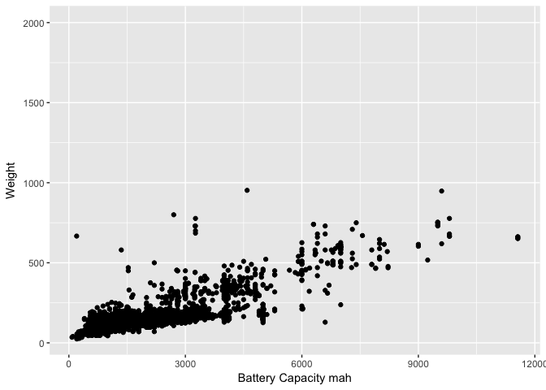

```r
library(ggplot2)
library(readr)
library(dplyr)

mobile = read_csv("../../Data/mobile_data.csv")

p_b_w = ggplot(data = mobile, aes(y = weight, x = battery_mah)) + geom_point(stat="identity") + xlab("Battery Capacity mah") + ylab("Weight")
p_b_w
```

```r
# The correlation between weight and battery size in mah
mbw = mobile[which(!is.na(mobile$battery_mah) & !is.na(mobile$weight)),]
c = cor(mbw$battery_mah, mbw$weight)
print(c)
```

```
[1] 0.8086273
```

۹. قیمت پرچمداران یک برند خاص مثلا سامسونگ را بیابید و نمودار قیمت زمان و نام مدل را رسم نمایید.

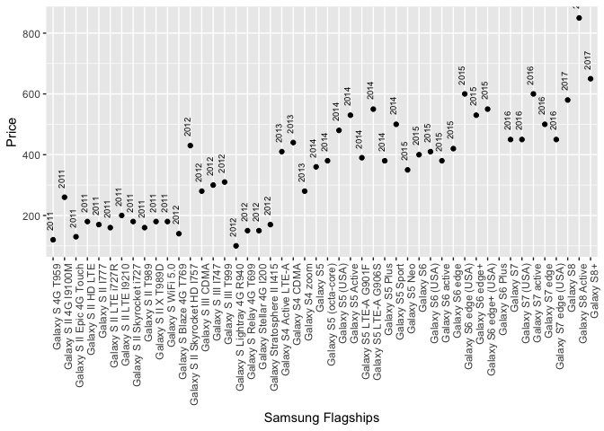

```r
library(ggplot2)
library(readr)
library(dplyr)

mobile = read_csv("../../Data/mobile_data.csv")

samsung = mobile[which(mobile$company == "Samsung"),]
samsung_flagship = samsung[grepl("^Galaxy S", samsung$device),]
samsung_flagship = samsung_flagship[!grepl("*mini", samsung_flagship$device),]
samsung_flagship = samsung_flagship[!grepl("*TV", samsung_flagship$device),]
samsung_flagship = samsung_flagship[!grepl("*Duos", samsung_flagship$device),]
samsung_flagship = samsung_flagship[!grepl("*Star*", samsung_flagship$device),]

p = ggplot(samsung_flagship, aes(x = reorder(device, year), y = price)) + geom_point() + theme(axis.text.x = element_text(angle = 90, hjust = 1)) + xlab("Samsung Flagships") + ylab("Price") + geom_text(aes(label=year),angle = 90, hjust=-0.5, vjust=0, size = 2.5)
p
```

پرچمداران سامسنوگ همگی با عبارت Galaxy S شروع می شوند و عباراتی مانند mini نباید در آن ها موجود باشد.

۱۰. سه نمودار جالب رسم کنید و توضیح دهید چرا از نظر شما جالب است؟

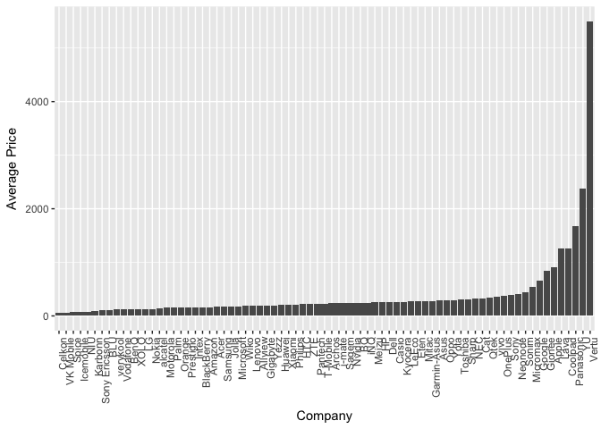

```r
library(ggplot2)
library(readr)
library(dplyr)

mobile = read_csv("../../Data/mobile_data.csv")
mobile = mobile[which(mobile$company != "QMobile"),]

# average price of mobiles of a company
company_average_price = mobile %>% group_by(company) %>% summarise(average_price = mean(price, na.rm = TRUE)) %>% filter(!is.na(average_price))
p_1 = ggplot(company_average_price, aes(x = reorder(company, average_price) , y = average_price)) + geom_bar(stat="identity") + theme(axis.text.x = element_text(angle = 90, hjust = 1)) + xlab("Company") + ylab("Average Price")
p_1
```

این نمودار میانگین قیمت گوشی های هر کمپانی را نشان می دهد و از این نظر برای من جذابیت داشت که این میانگین را با آمار فروششان مقایسه کنم.

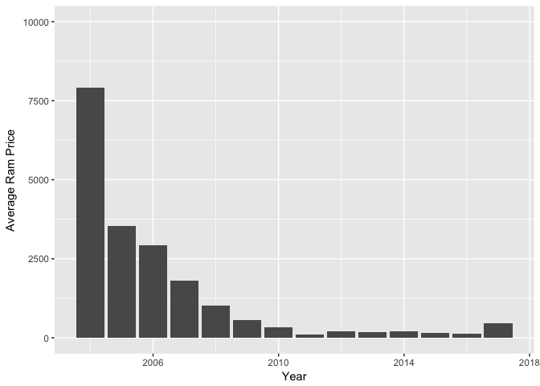

```r
# avrage price for 1 Gb ram in years
ram_average_price = mobile %>% group_by(year) %>% summarise(price_avg = mean(price, na.rm = TRUE), ram_avg = mean(ram, na.rm = TRUE)) %>% mutate(ram_avg_price_year = price_avg/ram_avg ) %>% filter(!is.na(ram_avg_price_year))
p_2 = ggplot(ram_average_price, aes(x = year , y = ram_avg_price_year)) + geom_bar(stat="identity")  + xlab("Year") + ylab("Average Ram Price") + ylim(0 , 10000)
p_2
```

جذابیت این نمودار برای من در این بود که شیب ارزان شدن تکنولوژی را مشاهده کنم.

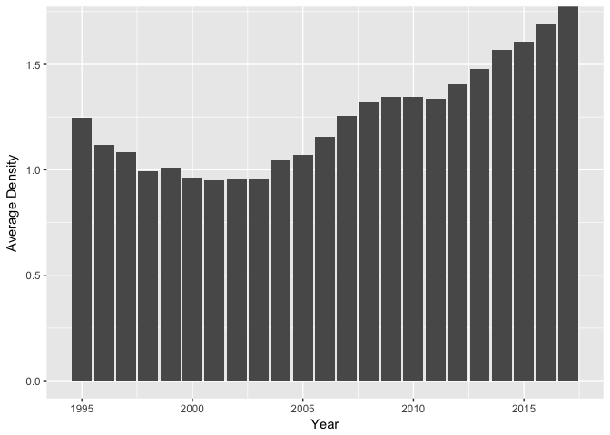

```r
# avreage density of mobiles in years
mobile_dnst = mobile %>% mutate(dnst = (weight/((dim_length)*(dim_thickness)*(dim_breadth)))*1000) %>% filter(!is.na(dnst))
mobile_dnst = mobile_dnst %>% group_by(year) %>% summarise(avg_dnst = mean(dnst , na.rm = TRUE))
p_3 = ggplot(mobile_dnst, aes(x = year , y = avg_dnst)) + geom_bar(stat="identity")  + xlab("Year") + ylab("Average Density")
p_3
```

جذابیت این نمودار برای من در این بود که روند تغییرات چگالی را در گوشی ها در سال های اشاره شده در نمودار بررسی کنم.